# Technical notes on soilflux4cast

- Environmental drivers: Daily
- Fluxes: Daily

## Environmental drivers

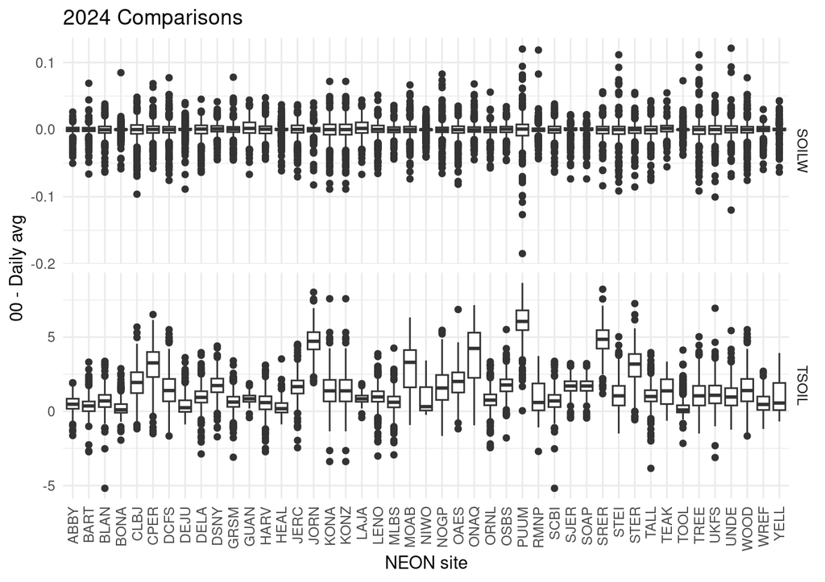

Environmental drivers comparison - UTC vs daily average

In addition, the comparison between measured surface temperature and soil water from the most shallow sites at shows good convergence between soil temperature (using the 00 UTC values for both NEON and GEFS), but less so for soil water, expressed in the following Taylor diagram.

A Taylor diagram is displayed on a polar coordinate plot with the radius equal to the standard deviation of a measurement from NEON. The horizontal axis of the Taylor diagram contains the standard deviation of the a measurement from NEON. The azimuthal angle in the Taylor diagram is the correlation coefficient *r* between the GEFS and NEON. In addition, the centered root mean square difference between the two datasets values can be inferred with isoclines that are concentric circles centered at the reference standard deviation. For ease of comparison with several different sites, the quantities shown on a Taylor diagram are normalised by the reference standard deviation. Different colors represent a NEON site, shapes the averaging period (00 or across the entire day).

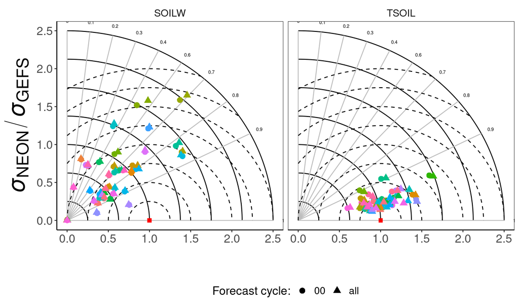

Environmental drivers comparison - Taylor Diagrams

## Flux averaging period

We compared the differences in fluxes averaged over a UTC day, compared to the local time. Because of seasonality we compare each NEON site each month

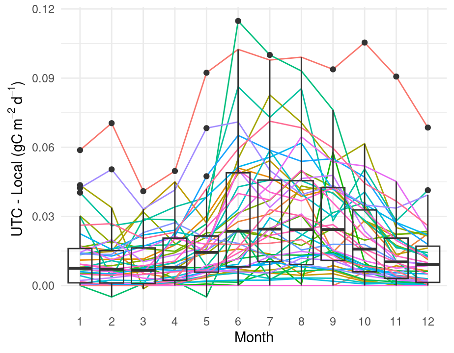

Flux timeseries comparison